# Survival Time Prediction for Breast Cancer Patients

## Results and Discussion

```r
names(coef(m1))
```

```
##  [1] "(Intercept)"
##  [2] "relapse_free"
##  [3] "relapse_statusRecurred"
##  [4] "vital_statusDied of Other Causes"
##  [5] "vital_statusLiving"
##  [6] "npi"
##  [7] "pr_statusPositive"
##  [8] "age"
##  [9] "chemoYes"
## [10] "inf_menoPre"
## [11] "survivalLiving"
## [12] "tumor_stage1"
## [13] "tumor_stage2"
## [14] "tumor_stage3"
## [15] "tumor_stage4"
```

[output cut: 24 more lines]

The high $R^2$ value of 0.927 tells us that our model predictors are effective in explaining the variation in survival time. However, an RMSE of 19.952 seems too high to be useful in a real-world scenario. We would like to be able to predict a survival time of a patient with a much smaller margin of error. Our model also fails to meet the constant variance and normality assumptions.

I would like to note that our dataset was small to begin with and it had a lot of missing values. A fair amount of data cleaning had to be performed just to be able to perform the analyses. And ideally, I would only consider data of patients that had already died due to breast cancer. Our dataset contains information on living patients and those that have died to other causes but removing this data would’ve left us with too little data to work with. Also, I’m only looking at clinical attributes of a patient in order to predict the survival time. In a real-world application, I would most likely consider other medical data such as genomic data to make these predictions.

## Appendix

Supplementary information on METABRIC dataset which includes description of `cohort`:

https://www.thno.org/v08/p6386/thnov08p6386s1.pdf

**Section 1.1**

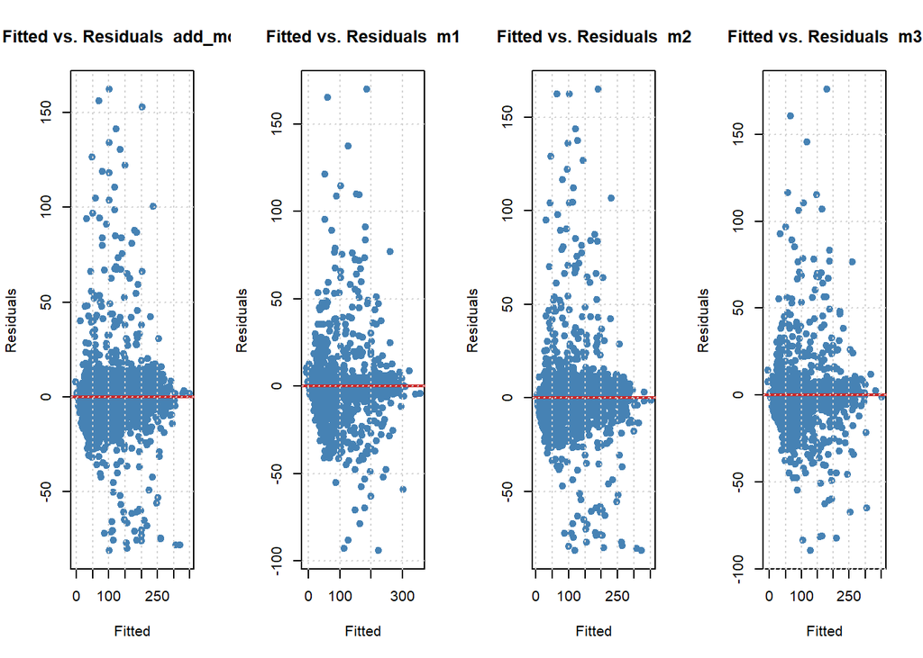

```r
par(mfrow = c(1, 4))
plot_fit_resid(add_model, title = "add_model")
plot_fit_resid(m1, title = "m1")
plot_fit_resid(m2, title = "m2")
plot_fit_resid(m3, title = "m3")
```

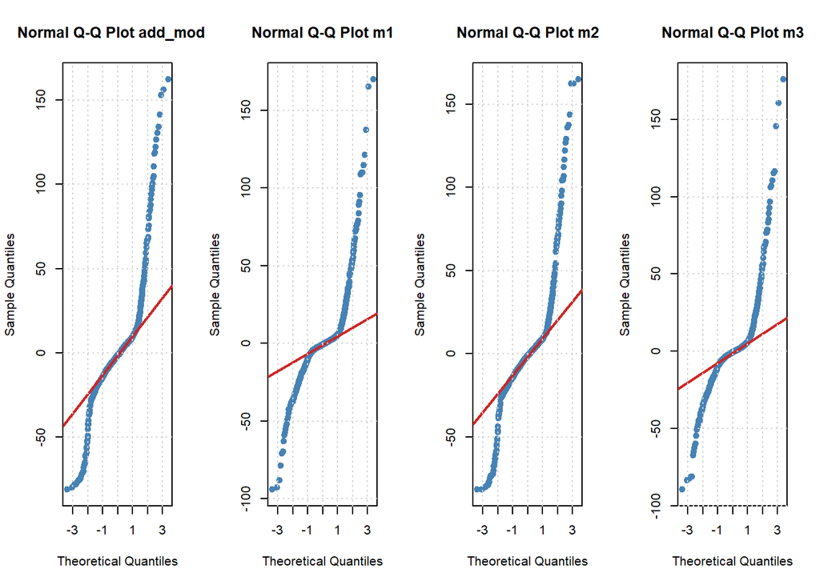

```r
par(mfrow = c(1, 4))
qqplot(add_model, title = "add_model")
qqplot(m1, title = "m1")
qqplot(m2, title = "m2")
qqplot(m3, title = "m3")
```

```r
add_model_bp = bptest(add_model)$p.value
m1_bp = bptest(m1)$p.value
m2_bp = bptest(m2)$p.value
m3_bp = bptest(m3)$p.value


add_model_sh = shapiro.test((resid(add_model)))$p.value
m1_sh = shapiro.test(resid(m1))$p.value
m2_sh = shapiro.test(resid(m2))$p.value
m3_sh = shapiro.test(resid(m3))$p.value

model_names = c("add_model", "m1", "m2", "m3")
bps = c(add_model_bp, m1_bp, m2_bp, m3_bp)
shs = c(add_model_sh, m1_sh, m2_sh, m3_sh)

model_data = data.frame(model_names,
                       bps,
                       shs)

kable(model_data, row.names = FALSE, align="c",
     col.names = c("Model",
                   "BP Test P-value",
                   "Shapiro Test P-value"),
     digits = 88) %>%
kable_styling(bootstrap_options = c("striped", "hover", "condensed", "responsive"))
```

| Model | BP Test P-value | Shapiro Test P-value |
| --- | --- | --- |
| add_model | 5.64e-44 | 5.67e-40 |
| m1 | 9.82e-33 | 1.46e-42 |
| m2 | 1.92e-53 | 6.52e-41 |
| m3 | 6.27e-28 | 1.83e-42 |